# MB5370 Module 04. Data Science in R 2

Ivanya Johnson

2024-08-27

# WORKSHOP 2: Using ggplot2 for Communication

## Load packages

Loading the tidyverse and ggplot2 packages. I set my preferences to use dplyr functions over others and loaded any other packages that come with ggplot and tidyverse.

```r
library(tidyverse)
library(conflicted)
library(dplyr)

conflicts_prefer(dplyr::filter) # Use to set preferences
```

```
## [conflicted] Will prefer dplyr::filter over any other package.
```

```r
conflicts_prefer(dplyr::lag) # Use to set preferences
```

```
## [conflicted] Will prefer dplyr::lag over any other package.
```

```r
library(ggthemes)

library(ggplot2)
```

## Load the data (mpg is built into ggplot2)

For this workshop, we will focus on the mpg and diamonds data.

```r
data("mpg")

data("diamonds")
```

## Labels

You can add labels to your graphs when plotting with ggplot. These include titles, subtitles, captions, and x and y labels.

### Adding a Title

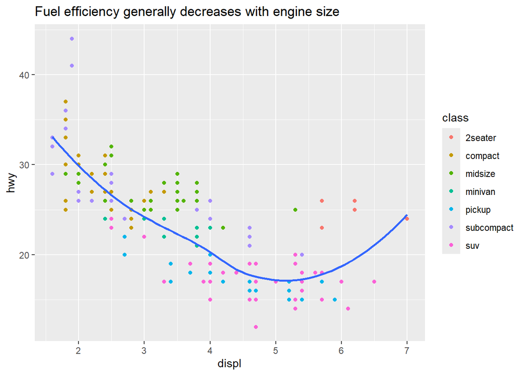

```r
ggplot(mpg, aes(displ, hwy)) +
  geom_point(aes(color = class)) +
  geom_smooth(se = FALSE) +
  labs(title = "Fuel efficiency generally decreases with engine size")
```

### Adding a subtitle and caption

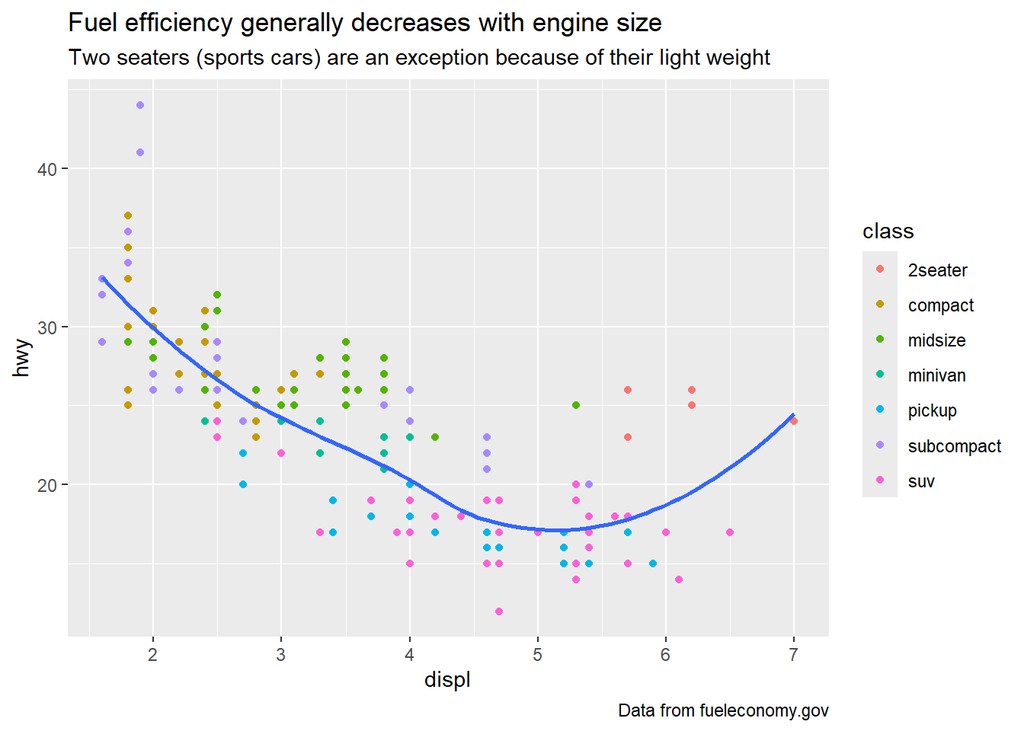

```r
ggplot(mpg, aes(displ, hwy)) +
  geom_point(aes(color = class)) +
  geom_smooth(se = FALSE) +
  labs(
    title = "Fuel efficiency generally decreases with engine size",
    subtitle = "Two seaters (sports cars) are an exception because of their light weight",
    caption = "Data from fueleconomy.gov"
  )
```

### Adding x and y labels

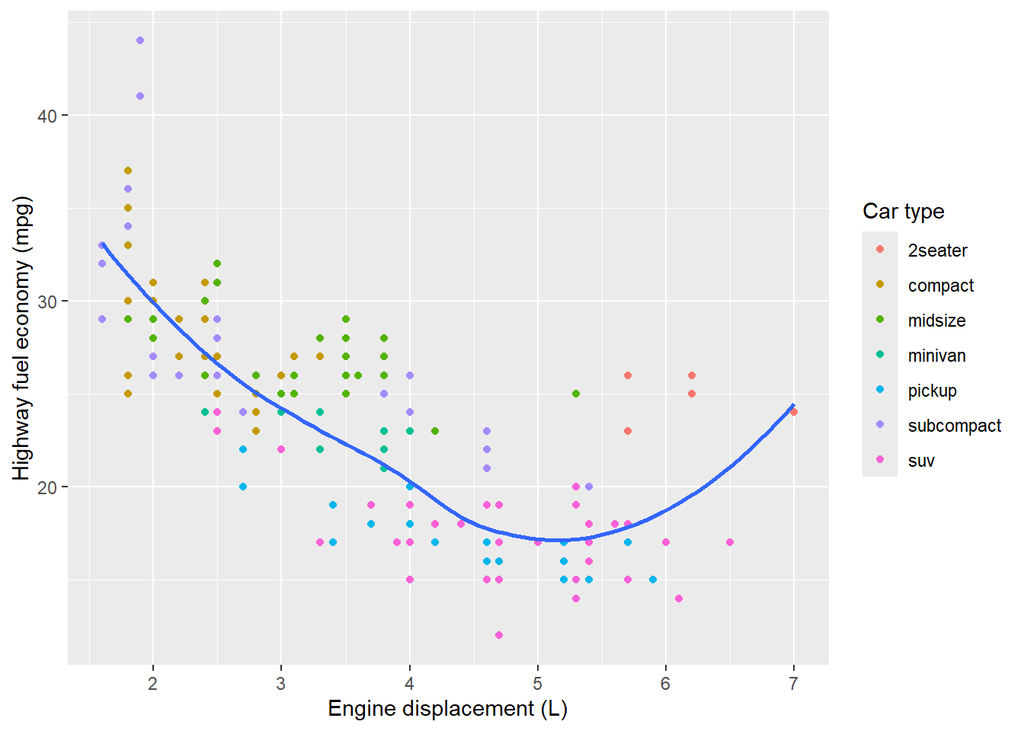

```r
ggplot(mpg, aes(displ, hwy)) +
  geom_point(aes(color = class)) +
  geom_smooth(se = FALSE) +
  labs(
    x = "Engine displacement (L)",
    y = "Highway fuel economy (mpg)",
    colour = "Car type"
  )
```

## Annotations

Annotations are used to add text to the actual plot. Sometimes you’ll want to do this to highlight a single observation. You can use geom_text() to add textual labels to your plots. This works in the same way as geom_point() but rather than a shape geometry it can add a label.

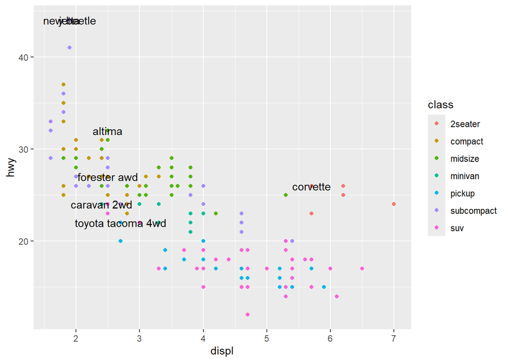

```r
best_in_class <- mpg %>%
  group_by(class) %>%
  filter(row_number(desc(hwy)) == 1)

ggplot(mpg, aes(displ, hwy)) +
  geom_point(aes(color = class)) +
  geom_text(aes(label = model), data = best_in_class)
```